```python
import warnings
warnings.filterwarnings('ignore')
import pandas as pd
import numpy as np
import matplotlib.pyplot as plt
import datetime
from dateutil.relativedelta import *
import matplotlib.pyplot as plt
from scipy import stats
import seaborn as sns
from scipy.stats.mstats import winsorize
import seaborn as sns
from fbprophet import Prophet
from fbprophet.plot import add_changepoints_to_plot

from sklearn.manifold import TSNE
from sklearn.decomposition import PCA, TruncatedSVD
import matplotlib.patches as mpatches
import xgboost as xgb
from xgboost import plot_importance, plot_tree

from sklearn.linear_model import LogisticRegression
from sklearn.svm import SVC
from sklearn.neighbors import KNeighborsClassifier
from sklearn.tree import DecisionTreeClassifier
from sklearn.ensemble import RandomForestClassifier
data_path = '/Users/terrenceshi/Desktop/Eugene/ChicagoData/'
```

# Part 1: The summary statistics of Violent Crimes

In this section, I use tables and figures to address the most relevant descriptive statistics to help my analysis in the next two parts.

## Data Quality

```python
data_part1 = pd.read_csv(str(data_path)+'Chicago_Crimes_2001_to_2004.csv', error_bad_lines=False, index_col=0,
                        parse_dates = ['Date'], engine='c')
data_part2 = pd.read_csv(str(data_path)+'Chicago_Crimes_2005_to_2007.csv', error_bad_lines=False, index_col=0,
                        parse_dates = ['Date'], engine='c')
data_part3 = pd.read_csv(str(data_path)+'Chicago_Crimes_2008_to_2011.csv', error_bad_lines=False, index_col=0,
                        parse_dates = ['Date'], engine='c')
data_part4 = pd.read_csv(str(data_path)+'Chicago_Crimes_2012_to_2017.csv', error_bad_lines=False, index_col=0,
                        parse_dates = ['Date'], engine='c')

data_concat = pd.DataFrame(pd.concat([data_part1, data_part2, data_part3, data_part4]))
```

```
b'Skipping line 1513591: expected 23 fields, saw 24\n'
b'Skipping line 533719: expected 23 fields, saw 24\n'
b'Skipping line 1149094: expected 23 fields, saw 41\n'
```

```python
data_concat['Primary Type'].value_counts()
```

```
THEFT                                1640506
BATTERY                              1442716
CRIMINAL DAMAGE                       923000
NARCOTICS                             885431
OTHER OFFENSE                         491922
ASSAULT                               481661
BURGLARY                              470958
MOTOR VEHICLE THEFT                   370548
ROBBERY                               300453
DECEPTIVE PRACTICE                    280931
CRIMINAL TRESPASS                     229366
PROSTITUTION                           86401
WEAPONS VIOLATION                      77429
PUBLIC PEACE VIOLATION                 58548
OFFENSE INVOLVING CHILDREN             51441
CRIM SEXUAL ASSAULT                    29868
SEX OFFENSE                            28707
GAMBLING                               18806
LIQUOR LAW VIOLATION                   17513
INTERFERENCE WITH PUBLIC OFFICER       15710
ARSON                                  13097
HOMICIDE                                9051
KIDNAPPING                              7756
INTIMIDATION                            4636
STALKING                                3734
OBSCENITY                                496
PUBLIC INDECENCY                         163
OTHER NARCOTIC VIOLATION                 144
NON-CRIMINAL                              97
CONCEALED CARRY LICENSE VIOLATION         90
NON - CRIMINAL                            38
RITUALISM                                 31
HUMAN TRAFFICKING                         28
NON-CRIMINAL (SUBJECT SPECIFIED)           4
DOMESTIC VIOLENCE                          2
Name: Primary Type, dtype: int64
```

- 2001-2004: 1,923,515 crimes, a bad line (line 1513591)
- 2005-2007: 1,872,343 crimes, a bad line (line 533719)
- 2008-2011: 2,688,710 crimes, a bad line (line 1149094)
- 2012-2017: 1,456,714 crimes, no bad lines

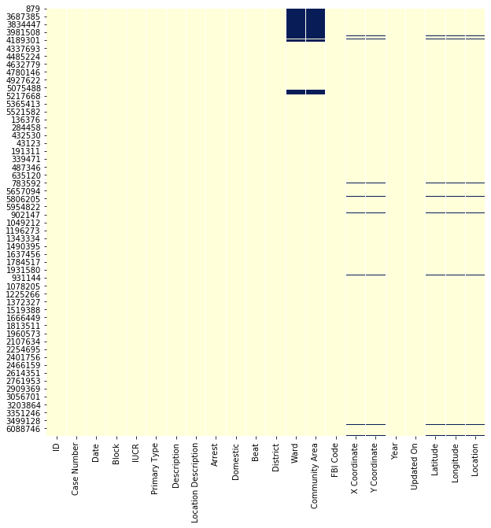

```python
# Show null values
plt.figure(figsize=(10,10))
sns.heatmap(data_concat.isnull(),cbar=False,cmap='YlGnBu')
plt.show()
```

In early years, a large portion of observations have missing location-related variables. The data is of good quality in recent years.

## Violent Crimes

Following the definition of National Institute of Justice, I define the following types of crimes as violent crimes:

```python
violent_crime = ['BATTERY', 'ASSAULT', 'ROBBERY', 'CRIM SEXUAL ASSAULT', 'SEX OFFENSE', 'HOMICIDE',
                 'KIDNAPPING', 'ARSON', 'OFFENSE INVOLVING CHILDREN']
```

```python
keep_column = ['ID', 'Case Number', 'Date', 'Block', 'Primary Type', 'Description', 'Location Description',
               'District', 'Community Area', 'Arrest']
data_concat = data_concat[keep_column]
data_concat['Violent_crime'] = 'Non-Violent Crime'
data_concat['Violent_crime'] = data_concat['Violent_crime'].where(data_concat['Primary Type']
                                                                  .apply(lambda x: x not in violent_crime),
                                                                  'Violent Crime')
data_concat['year'] = data_concat['Date'].dt.year
```

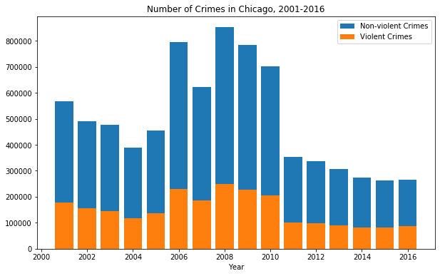

| year Violent_crime | 2001 | 2002 | 2003 | 2004 | 2005 | 2006 | 2007 | 2008 | 2009 | 2010 | 2011 | 2012 | 2013 | 2014 | 2015 | 2016 |
| --- | --- | --- | --- | --- | --- | --- | --- | --- | --- | --- | --- | --- | --- | --- | --- | --- |
| Non-Violent Crime | 391012 | 335979 | 331714 | 272052 | 320454 | 565879 | 437243 | 602451 | 556842 | 496578 | 250987 | 237309 | 217287 | 192748 | 181790 | 178441 |
| Violent Crime | 177506 | 154900 | 144199 | 116153 | 135357 | 228805 | 184605 | 249602 | 227058 | 204113 | 101079 | 98361 | 89416 | 81779 | 81205 | 87021 |

```python
# violent crimes and non-violent crimes by year
from matplotlib import pyplot as plt
fig,ax=plt.subplots(figsize=(10,6))

data_count = data_concat.groupby(['Violent_crime','year'])['Date'].count().unstack(level=-1).drop([2017], axis=1)

year=[int(i) for i in data_count.columns]
value=data_count.T.values
v1=[i[0]+i[1] for i in value]
v2=[i[1] for i in value]

ax.bar(year,v1)
ax.bar(year,v2)
ax.set(xlabel="Year",title="Number of Crimes in Chicago, 2001-2016")
ax.legend(["Non-violent Crimes", "Violent Crimes"])
plt.show()
data_count
```

Both crimes and violent crimes peaked around 2008-2009 (Is it related to finance crisis?). On average 30% crimes are violent crimes in our sample.  
As the next step, we examine the distribution of violent crimes using a pie chart as follows:

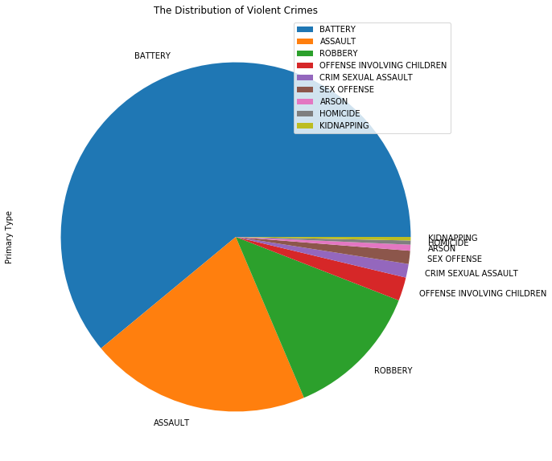

```python
vcrimes = data_concat[data_concat['Violent_crime'] == 'Violent Crime']
vcrimes_count = pd.DataFrame(vcrimes['Primary Type'].value_counts())
plot = vcrimes_count.plot.pie(y='Primary Type', figsize=(10, 10))
plt.title('The Distribution of Violent Crimes')
```

## Seasonality

Firstly, I plot the number of crimes per month to confirm the fluctuations of the number of crimes show regular patterns.

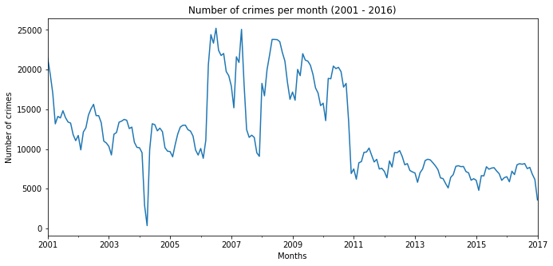

```python
plt.figure(figsize=(11,5))
vcrimes.set_index(['Date']).resample('M').size().plot(legend=False)
plt.title('Number of crimes per month (2001 - 2016)')
plt.xlabel('Months')
plt.ylabel('Number of crimes')
plt.show()
```

Further, we plot the number of all violent crimes (homicide) by month. Violent crimes are the most frequent in May while homicide peaks in July.

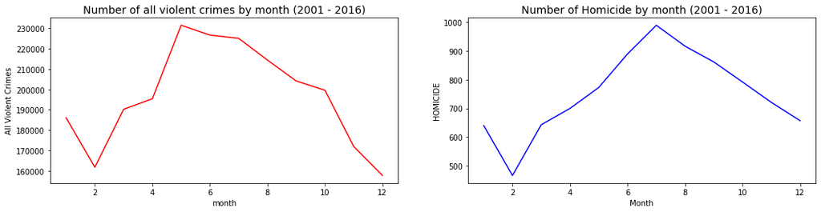

```python
# Violent crimes increase rate by month
vcrimes['month']=vcrimes['Date'].dt.month
vcrimes['time']=vcrimes['Date'].dt.hour
vcrimes['weekday']=vcrimes['Date'].dt.weekday
data_count = pd.DataFrame(vcrimes.groupby(['month'])['Date'].count()).\
    join(pd.DataFrame(vcrimes[vcrimes['Primary Type']=='HOMICIDE'].groupby(['month'])['ID'].count())).reset_index()
data_count.columns = ['month', 'All Violent Crimes', 'HOMICIDE']
fig, ax = plt.subplots(1, 2, figsize=(18,4))
v_val = data_count['All Violent Crimes'].values
h_val = data_count['HOMICIDE'].values

sns.lineplot(x="month", y="All Violent Crimes", data=data_count, ax=ax[0], color='r')
ax[0].set_title('Number of all violent crimes by month (2001 - 2016)', fontsize=14)

sns.lineplot(x="month", y="HOMICIDE", data=data_count, ax=ax[1], color='b')
ax[1].set_title('Number of Homicide by month (2001 - 2016)', fontsize=14)

plt.xlabel('Month')
plt.show()
```

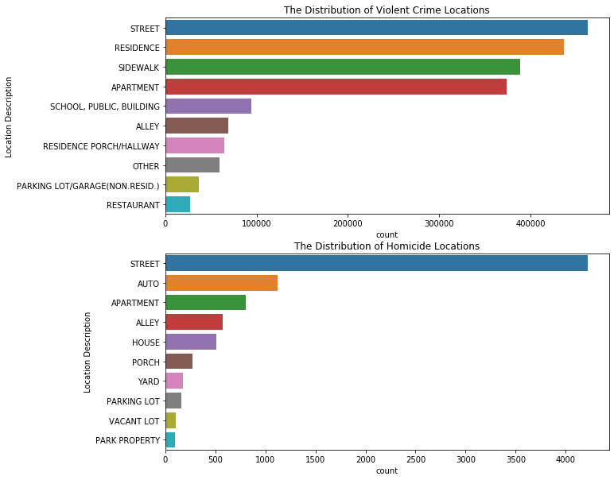

```python
fig, ax = plt.subplots(2, 1, figsize=(10,10))
vcrimes_count = pd.DataFrame(vcrimes['Location Description'].value_counts().sort_values(ascending=False).iloc[:7])
sns.countplot(y= 'Location Description', data = vcrimes, ax = ax[0],
              order = vcrimes['Location Description'].value_counts().iloc[:10].index)
ax[0].set_title('The Distribution of Violent Crime Locations')

vcrimes_homicide=vcrimes[vcrimes['Primary Type']=='HOMICIDE']
vcrimes_count = pd.DataFrame(vcrimes_homicide['Location Description'].value_counts().\
                             sort_values(ascending=False).iloc[:7])
sns.countplot(y= 'Location Description', data = vcrimes_homicide, ax = ax[1],
              order = vcrimes_homicide['Location Description'].value_counts().iloc[:10].index)
ax[1].set_title('The Distribution of Homicide Locations')
```

## Weather and Violent Crimes

```python
# Climate Data
temperature = pd.read_csv(str(data_path) + 'temperature.csv', error_bad_lines=False)
temperature = temperature[['datetime', 'Chicago']]
temperature['datetime'] = pd.to_datetime(temperature['datetime'])
temperature['date'] = temperature['datetime'].dt.date
temperature['Daily_temp'] = temperature.groupby(['date'])['Chicago'].transform(np.mean)
temperature['MAver_temp_6h'] = temperature.sort_values(by=['datetime'])['Chicago'].rolling(window=6).mean().shift()
temperature['temp_max'] = temperature.groupby(['date'])['Chicago'].transform(np.max)
temperature['temp_min'] = temperature.groupby(['date'])['Chicago'].transform(np.min)
vcrime_weather = pd.merge(vcrimes.rename(columns={'Date':'datetime'}), temperature, on=['datetime'])
vcrime_weather = vcrime_weather[~vcrime_weather['Chicago'].isnull()].rename(columns={'Chicago':'temperature'})
```

We consider the hourly temperature and weather description data. Based on weather descriptions, we produce some dummy variables, including:

- rain_dummy: A dummy variable equals 1 if weather description contains word ‘rain’ or ‘drizzle’
- snow_dummy: A dummy variable equals 1 if weather description contains word ‘snow’
- storm_dummy: A dummy variable equals 1 if weather description contains word ‘thunderstorm’
- heavy_list: A dummy variable equals 1 if weather description contains word ‘heavy’, ‘shower’, ‘thunderstorm’, ‘freezing’
- fog_list: A dummy variable equals 1 if weather description contains word ‘fog’, ‘haze’

```python
weather = pd.read_csv(str(data_path) + 'weather_description.csv', error_bad_lines=False)
weather = weather[['datetime', 'Chicago']]
weather_list = list(set(weather['Chicago']))
weather_list = [x for x in weather_list if x is not np.nan]
```

```python
rain_list = [x for x in weather_list if (('rain' in x) | ('drizzle' in x))]
snow_list = [x for x in weather_list if 'snow' in x]
storm_list = [x for x in weather_list if 'thunderstorm' in x]
heavy_list = [x for x in weather_list if ('heavy' in x) | ('shower' in x) | ('thunderstorm' in x) |('freezing' in x)]
fog_list = [x for x in weather_list if ('fog' in x) | ('haze' in x)]
```

```python
weather['rain_dummy'] = 0
weather['rain_dummy'] = weather['rain_dummy'].where(weather['Chicago'].apply(lambda x: x not in rain_list), 1)
weather['snow_dummy'] = 0
weather['snow_dummy'] = weather['snow_dummy'].where(weather['Chicago'].apply(lambda x: x not in snow_list), 1)
weather['storm_dummy'] = 0
weather['storm_dummy'] = weather['storm_dummy'].where(weather['Chicago'].apply(lambda x: x not in storm_list), 1)
weather['heavy_dummy'] = 0
weather['heavy_dummy'] = weather['heavy_dummy'].where(weather['Chicago'].apply(lambda x: x not in heavy_list), 1)
weather['fog_dummy'] = 0
weather['fog_dummy'] = weather['fog_dummy'].where(weather['Chicago'].apply(lambda x: x not in fog_list), 1)

weather['datetime'] = pd.to_datetime(weather['datetime'])
vcrime_weather = pd.merge(vcrime_weather, weather, on=['datetime'])
```

Using a histogram, we examine the distribution violent crimes by temperature. More violent crimes happen in high temperature between 290 K and 300 K.

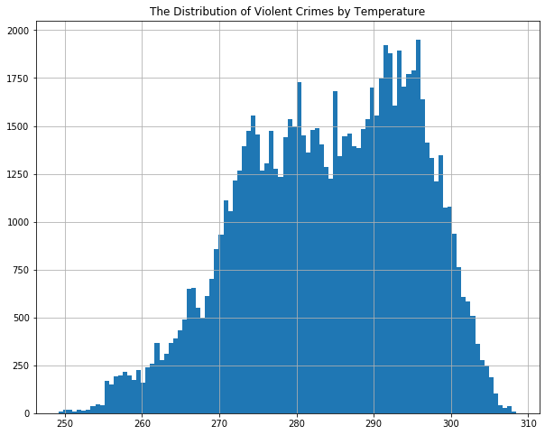

```python
plt.figure(figsize=[10,8])
vcrime_weather['temperature'].hist(bins=100)
plt.title('The Distribution of Violent Crimes by Temperature')
```

Finally, we show the summary statistics of main variables and the mean values of main variables by violent crime primary types.

```python
vcrime_weather[['temperature', 'Daily_temp', 'MAver_temp_6h', 'temp_max', 'temp_min',
                'rain_dummy', 'snow_dummy', 'storm_dummy', 'heavy_dummy', 'fog_dummy']].describe().round(3)
```

|  | temperature | Daily_temp | MAver_temp_6h | temp_max | temp_min | rain_dummy | snow_dummy | storm_dummy | heavy_dummy | fog_dummy |
| --- | --- | --- | --- | --- | --- | --- | --- | --- | --- | --- |
| count | 88499.000 | 88499.000 | 88462.000 | 88499.000 | 88499.000 | 88499.000 | 88499.000 | 88499.000 | 88499.000 | 88499.000 |
| mean | 284.191 | 283.867 | 283.802 | 288.348 | 280.241 | 0.151 | 0.027 | 0.007 | 0.026 | 0.027 |
| std | 11.115 | 10.496 | 10.957 | 11.039 | 10.313 | 0.358 | 0.162 | 0.083 | 0.160 | 0.164 |
| min | 249.184 | 252.618 | 249.490 | 255.842 | 248.890 | 0.000 | 0.000 | 0.000 | 0.000 | 0.000 |
| 25% | 275.780 | 276.019 | 275.615 | 279.810 | 272.890 | 0.000 | 0.000 | 0.000 | 0.000 | 0.000 |
| 50% | 285.150 | 284.611 | 284.542 | 289.400 | 280.977 | 0.000 | 0.000 | 0.000 | 0.000 | 0.000 |
| 75% | 293.300 | 293.165 | 292.808 | 297.980 | 288.770 | 0.000 | 0.000 | 0.000 | 0.000 | 0.000 |
| max | 308.480 | 303.316 | 307.203 | 308.480 | 299.290 | 1.000 | 1.000 | 1.000 | 1.000 | 1.000 |

```python
vcrime_weather.groupby(['Primary Type'])[['temperature','temp_max', 'temp_min', 'rain_dummy', 'snow_dummy', 'storm_dummy',
                                          'heavy_dummy', 'fog_dummy']].mean().round(3).sort_values(by=['temperature'])
```

| Primary Type | temperature | temp_max | temp_min | rain_dummy | snow_dummy | storm_dummy | heavy_dummy | fog_dummy |
| --- | --- | --- | --- | --- | --- | --- | --- | --- |
| KIDNAPPING | 282.585 | 287.119 | 279.169 | 0.124 | 0.044 | 0.006 | 0.022 | 0.036 |
| OFFENSE INVOLVING CHILDREN | 282.603 | 286.750 | 278.841 | 0.159 | 0.032 | 0.006 | 0.031 | 0.026 |
| ASSAULT | 284.203 | 288.536 | 280.434 | 0.152 | 0.027 | 0.006 | 0.025 | 0.029 |
| SEX OFFENSE | 284.212 | 288.336 | 280.451 | 0.170 | 0.026 | 0.009 | 0.033 | 0.021 |
| BATTERY | 284.301 | 288.449 | 280.300 | 0.150 | 0.026 | 0.008 | 0.027 | 0.028 |
| CRIM SEXUAL ASSAULT | 284.400 | 288.315 | 280.325 | 0.162 | 0.028 | 0.005 | 0.026 | 0.029 |
| ROBBERY | 284.416 | 288.362 | 280.276 | 0.145 | 0.027 | 0.006 | 0.025 | 0.026 |
| HOMICIDE | 285.398 | 289.584 | 281.263 | 0.100 | 0.083 | 0.000 | 0.008 | 0.017 |
| ARSON | 285.635 | 289.739 | 281.583 | 0.147 | 0.024 | 0.004 | 0.024 | 0.028 |

# Part 2 Economics Analysis

```python
vcrime_hour = pd.DataFrame(vcrime_weather.set_index(['datetime']).resample('H').size()).\
    rename(columns={0:'vcrime_count'})
vcrime_hour['vcrime_dummy'] = vcrime_hour['vcrime_count'].astype(bool).astype(int)

homicide_hour = pd.DataFrame(vcrime_weather[vcrime_weather['Primary Type']=='HOMICIDE'].\
                             set_index(['datetime']).resample('H').size()).rename(columns={0:'homicide_count'})
homicide_hour['homicide_dummy'] = homicide_hour['homicide_count'].astype(bool).astype(int)
```

```python
pd_hour_combine = vcrime_hour.join(homicide_hour).join(temperature.set_index(['datetime']).rename(columns={'Chicago':'temperature'})).\
    join(weather.set_index(['datetime']).drop(['Chicago'], axis=1))
pd_hour_combine[['homicide_count','homicide_dummy']] = pd_hour_combine[['homicide_count','homicide_dummy']].fillna(0)
pd_hour_combine = pd_hour_combine.drop(['date'],axis=1).reset_index()
pd_hour_combine['month']=pd_hour_combine['datetime'].dt.month
pd_hour_combine['time']=pd_hour_combine['datetime'].dt.hour
pd_hour_combine['weekday']=pd_hour_combine['datetime'].dt.weekday
pd_hour_combine.to_csv(str(data_path) + 'Violent_Crime_Hourly.csv')
```

```python
pd_hour_combine['date'] = pd_hour_combine['datetime'].dt.date
pd_date = pd_hour_combine.groupby(['date'])['homicide_dummy', 'Daily_temp','temp_max', 'temp_min',
                                            'rain_dummy', 'snow_dummy', 'storm_dummy',
                                            'heavy_dummy', 'fog_dummy', 'month', 'time', 'weekday'].mean()
```

```python
pd_date['homicide_dummy'] = pd_date['homicide_dummy'].astype(bool).astype(int)
pd_date['rain_dummy'] = pd_date['rain_dummy'].where(pd_date['rain_dummy']>0.1, 0)
weather_dummy = ['rain_dummy', 'snow_dummy', 'storm_dummy', 'heavy_dummy', 'fog_dummy']
pd_date[weather_dummy] = pd_date[weather_dummy].astype(bool).astype(int)
pd_date.to_csv(str(data_path) + 'Violent_Crime_Daily.csv')
```

# Part 3 Predication Based Modeling

## Question: How many violent crimes would you predict during that hour?

```python
pd_hour_combine = pd.read_csv(str(data_path) + 'Violent_Crime_Hourly.csv')
# Exclude outliers of Violent crime count variables
print(pd.DataFrame(pd_hour_combine[['vcrime_count']].describe(percentiles=[0.99]).T))
pd_hour_combine['vcrime_count'] = pd_hour_combine['vcrime_count'].where(pd_hour_combine['vcrime_count']<=8, 8)
```

```
                count      mean       std  min  50%  99%   max
vcrime_count  37691.0  2.348014  1.890727  0.0  2.0  8.0  68.0
```

### Prophet

Prophet is a facebooks’ open source time series prediction. Prophet decomposes time series into trend, seasonality and holiday. It has intuitive hyper parameters which are easy to tune.

- Trend models non periodic changes in the value of the time series.
- Seasonality is the periodic changes like daily, weekly, or yearly seasonality.
- Holiday effect which occur on irregular schedules over a day or a period of days.
- Error terms is what is not explained by the model.

#### Baseline Model (Only use datatime variables in predictions)

```python
df_prophet = pd_hour_combine[['datetime', 'vcrime_count', 'temperature', 'rain_dummy']].\
    rename(columns={'datetime':'ds', 'vcrime_count':'y'}).dropna()
```

```python
m = Prophet()
m.fit(df_prophet)
```

```
<fbprophet.forecaster.Prophet at 0x7fe894847c10>
```

```python
# Merge with temperature and weather description
temperature = pd.read_csv(str(data_path) + 'temperature.csv', error_bad_lines=False)
temperature = temperature[['datetime', 'Chicago']]
temperature['datetime'] = pd.to_datetime(temperature['datetime'])
temperature.columns = ['ds', 'temperature']

weather = pd.read_csv(str(data_path) + 'weather_description.csv', error_bad_lines=False)
weather = weather[['datetime', 'Chicago']]
weather['datetime'] = pd.to_datetime(weather['datetime'])
weather_list = list(set(weather['Chicago']))
weather_list = [x for x in weather_list if x is not np.nan]
rain_list = [x for x in weather_list if (('rain' in x) | ('drizzle' in x))]
weather['rain_dummy'] = 0
weather['rain_dummy'] = weather['rain_dummy'].where(weather['Chicago'].apply(lambda x: x not in rain_list), 1)
weather = weather[['datetime', 'rain_dummy']].rename(columns ={'datetime':'ds'})

df_prophet_2017 = pd.merge(temperature, weather, on=['ds'], how='left')
df_prophet_2017 = df_prophet_2017[df_prophet_2017['ds']>='2017-01-19']
df_prophet_Baseline = pd.DataFrame(pd.concat([df_prophet, df_prophet_2017]))
```

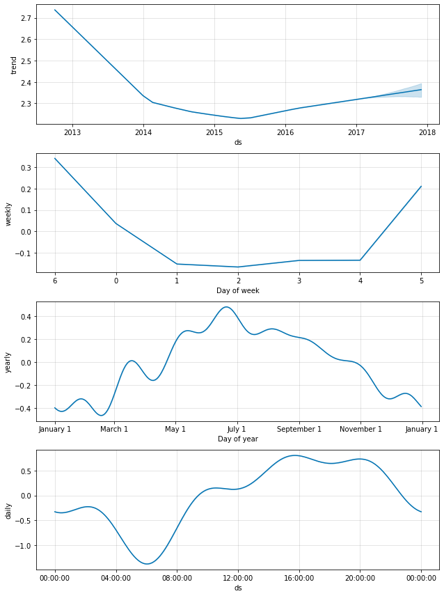

```python
forecast_baseline = m.predict(df_prophet_Baseline)
figure_baseline = m.plot_components(forecast_baseline)
```

#### Add Temperature and Rainy binary variable as additional regressors

```python
m = Prophet()
m.add_regressor('temperature')
m.add_regressor('rain_dummy')
m.fit(df_prophet)
```

```
<fbprophet.forecaster.Prophet at 0x7fe8967bc5d0>
```

```python
# Merge with temperature and weather description
df_prophet_weather = pd.DataFrame(pd.concat([df_prophet, df_prophet_2017]))
```

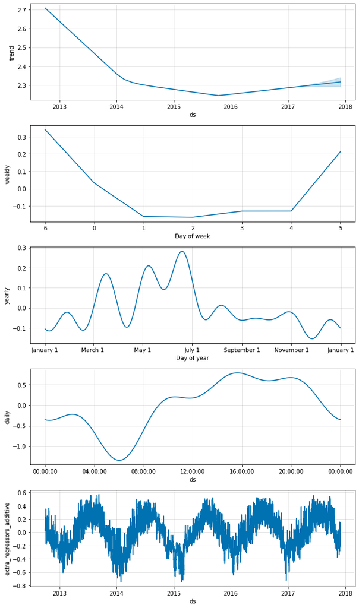

```python
forecast_weather = m.predict(df_prophet_weather)
#forecast_weather = forecast_weather.merge(df_prophet_weather, on=['ds'])
figure_weather = m.plot_components(forecast_weather)
```

### Poisson Count Regression and XGB

```python
for xday in list(set(pd_hour_combine['month'])):
    pd_hour_combine['month'+str(xday)] = 0
    pd_hour_combine['month'+str(xday)] = pd_hour_combine['month'+str(xday)].where(pd_hour_combine['month']!=xday,1)

for xday in list(set(pd_hour_combine['weekday'])):
    pd_hour_combine['weekday'+str(xday)] = 0
    pd_hour_combine['weekday'+str(xday)] = pd_hour_combine['weekday'+str(xday)].where(pd_hour_combine['weekday']!=xday,1)

for xday in list(set(pd_hour_combine['time'])):
    pd_hour_combine[str(xday)+':00'] = 0
    pd_hour_combine[str(xday)+':00'] = pd_hour_combine[str(xday)+':00'].where(pd_hour_combine['time']!=xday,1)
```

```python
month_name = {'month1': 'Jan', 'month2':'Feb', 'month3':'Mar', 'month4':'Apr', 'month5':'May', 'month6':'Jun',
             'month7':'July', 'month8':'Aug', 'month9':'Sep', 'month10':'Oct', 'month11':'Nov', 'month12':'Dec'}
weekday_name = {'weekday0': 'Sun', 'weekday1':'Mon', 'weekday2':'Tue', 'weekday3':'Wed', 'weekday4':'Thu',
                'weekday5':'Fri', 'weekday6':'Sat'}
pd_hour_combine = pd_hour_combine.rename(columns=month_name).rename(columns=weekday_name)
```

```python
dummy_list=['Jan', 'Feb', 'Mar', 'Apr', 'May', 'Jun', 'July', 'Aug', 'Sep', 'Oct',
             'Nov', 'Dec', 'Sun', 'Mon', 'Tue', 'Wed', 'Thu', 'Fri', 'Sat', '0:00',
             '1:00', '2:00', '3:00', '4:00', '5:00', '6:00', '7:00', '8:00', '9:00',
             '10:00', '11:00', '12:00', '13:00', '14:00', '15:00', '16:00', '17:00',
             '18:00', '19:00', '20:00', '21:00', '22:00', '23:00']

pd_train = pd_hour_combine[pd_hour_combine['datetime']<'2016-01-01 00:00:00'].set_index('datetime').dropna()
pd_test = pd_hour_combine[pd_hour_combine['datetime']>='2016-01-01 00:00:00'].set_index('datetime').dropna()

X_train = pd_train[['temperature','rain_dummy'] + dummy_list]
y_train = pd_train['vcrime_count']
X_test = pd_test[['temperature','rain_dummy'] + dummy_list]
y_test = pd_test['vcrime_count']

X_train = X_train.values
X_test = X_test.values
y_train = y_train.values
y_test = y_test.values
```

```python
from sklearn.linear_model import PoissonRegressor
import xgboost as xgb
from xgboost import plot_importance, plot_tree
classifiers = {
    "Poisson": PoissonRegressor(),
    "XGBoost": xgb.XGBClassifier(objective='count:poisson')
}
```

```python
from sklearn.model_selection import GridSearchCV

# Logistic Regression
poisson_reg_params = {"alpha": [0,1,2,3]}
grid_ps_reg = GridSearchCV(PoissonRegressor(), poisson_reg_params)
grid_ps_reg.fit(X_train, y_train)
# We automatically get the logistic regression with the best parameters.
log_reg = grid_ps_reg.best_estimator_

# XGB Classifier
XGB_params = {'n_estimators':[50, 100, 200]}
grid_XGB = GridSearchCV(xgb.XGBClassifier(objective='count:poisson'), XGB_params)
grid_XGB.fit(X_train, y_train)
# XGB best estimator
XGB_clf = grid_XGB.best_estimator_
```

```python
glm = PoissonRegressor(alpha=0)
glm_model = glm.fit(X_train, y_train)

xgb_clf=xgb.XGBClassifier(objective='count:poisson', n_estimators=100, max_depth=2,
                          min_child_weight = 6, learning_rate = 0.2)
xgb_model = xgb_clf.fit(X_train, y_train)
```

### Validation and Comparison

```python
poisson_regression = pd.DataFrame(glm.fit(X_train, y_train).predict(X_test)).rename(columns={0:'Poisson Regression'})
XGB_poisson = pd.DataFrame(xgb_model.predict(X_test)).rename(columns={0:'XGB Poisson'})
pd_validation = pd_test['vcrime_count'].reset_index().join(poisson_regression).join(XGB_poisson)
pd_validation['xgb_mse'] = (pd_validation['XGB Poisson'] - pd_validation['vcrime_count']).apply(lambda x: x**2)
pd_validation['ps_mse'] = (pd_validation['Poisson Regression'] - pd_validation['vcrime_count']).apply(lambda x: x**2)
```

```python
pd_validation['datetime'] = pd.to_datetime(pd_validation['datetime'])
pd_validation = pd.merge(pd_validation,
                         forecast_baseline[['ds','yhat']].rename(columns={'ds':'datetime','yhat':'Prophet_baseline'})
                         ,on=['datetime'])
pd_validation = pd.merge(pd_validation,
                         forecast_weather[['ds','yhat']].rename(columns={'ds':'datetime','yhat':'Prophet_weather'}),
                        on=['datetime'])
pd_validation['pph_bl'] = (pd_validation['Prophet_baseline'] - pd_validation['vcrime_count']).apply(lambda x: x**2)
pd_validation['pph_wt'] = (pd_validation['Prophet_weather'] - pd_validation['vcrime_count']).apply(lambda x: x**2)
pd_validation[['ps_mse', 'xgb_mse', 'pph_bl', 'pph_wt']].mean()
```

[output not shown]

```python
pd_validation['xgb_mae'] = (pd_validation['XGB Poisson'] - pd_validation['vcrime_count']).apply(lambda x: abs(x))
pd_validation['ps_mae'] = (pd_validation['Poisson Regression'] - pd_validation['vcrime_count']).apply(lambda x: abs(x))
pd_validation['pphbl_mae'] = (pd_validation['Prophet_baseline'] - pd_validation['vcrime_count']).apply(lambda x: abs(x))
pd_validation['pphwt_mae'] = (pd_validation['Prophet_weather'] - pd_validation['vcrime_count']).apply(lambda x: abs(x))
pd_validation[['ps_mae', 'xgb_mae', 'pphbl_mae', 'pphwt_mae']].mean()
```

[output not shown]

```python
fig, ax = plt.subplots(2, 2, figsize=(15,15))
ax[0][1].hist(pd_validation['vcrime_count'], normed=True, color="#FF0000", alpha=.5)
ax[0][1].hist(pd_validation['XGB Poisson'], normed=True, color="#C1F320", alpha=.9)
ax[0][1].legend(["Violent Crimes", "XGB Poisson Prediction"])

ax[0][0].hist(pd_validation['vcrime_count'], normed=True, color="#FF0000", alpha=.5)
ax[0][0].hist(pd_validation['Poisson Regression'], normed=True, bins=100,color="#C1F320", alpha=.9)
ax[0][0].legend(["Violent Crimes", "Poisson Regression Prediction"])

ax[1][0].hist(pd_validation['vcrime_count'], normed=True, color="#FF0000", alpha=.5)
ax[1][0].hist(pd_validation['Prophet_baseline'], normed=True, bins=100, color="#C1F320", alpha=.9)
ax[1][0].legend(["Violent Crimes", "Prophet Baseline Prediction"])

ax[1][1].hist(pd_validation['vcrime_count'], normed=True, color="#FF0000", alpha=.5)
ax[1][1].hist(pd_validation['Prophet_weather'], normed=True, bins=100, color="#C1F320", alpha=.9)
ax[1][1].legend(["Violent Crimes", "Prophet model with weather as additional regressor Prediction"])
```

[output not shown]

## Question: What is the likelihood that she would expect a violent crime incident in the city during that hour?

### Binary Classification

#### Data Training

```python
pd_hour_combine['vcrime_count'].hist()
```

[output not shown]

```python
binary_data = pd_hour_combine[(pd_hour_combine['vcrime_count']==0) | (pd_hour_combine['vcrime_count'] >4)]
binary_data['vcrime_count'] = binary_data['vcrime_count'].astype(bool).astype(int)
pd.DataFrame(binary_data['vcrime_count'].value_counts())
```

[output not shown]

Some more observations are randomly choose from hours with 4 violent crimes to make the sample balanced.

```python
random_sample = pd_hour_combine[(pd_hour_combine['vcrime_count']==4)]
random_sample = random_sample.reset_index(drop=True).\
    join(pd.DataFrame(np.random.randint(low=0, high=4090, size = 4090))).set_index(0).sort_index()
random_sample = random_sample.head(5461-4612)
random_sample['vcrime_count'] = random_sample['vcrime_count'].astype(bool).astype(int)
binary_data = pd.DataFrame(pd.concat([binary_data, random_sample]))
pd.DataFrame(binary_data['vcrime_count'].value_counts())
```

[output not shown]

```python
binary_data = binary_data[['vcrime_count', 'temperature','rain_dummy'] + dummy_list].dropna()
X = binary_data[['temperature','rain_dummy'] + dummy_list]
y = binary_data['vcrime_count']
y.columns = ['vcrime_dummy']

from sklearn.model_selection import train_test_split

X_train, X_test, y_train, y_test = train_test_split(X, y, test_size=0.2, random_state=42)

X_train = X_train.values
X_test = X_test.values
y_train = y_train.values
y_test = y_test.values
```

```python
classifiers = {
    "LogisiticRegression": LogisticRegression(),
    "Support Vector Classifier": SVC(),
    "DecisionTreeClassifier": DecisionTreeClassifier(),
    "XGBoost": xgb.XGBClassifier()
}
```

```python
from sklearn.model_selection import cross_val_score
for key, classifier in classifiers.items():
    classifier.fit(X_train, y_train)
    training_score = cross_val_score(classifier, X_train, y_train, cv=5)
    print("Classifiers: ", classifier.__class__.__name__, "Has a training score of", round(training_score.mean(), 2) * 100, "% accuracy score")
```

[output not shown]

Use GridSearchCV to find the best parameters.

```python
from sklearn.model_selection import GridSearchCV

# Logistic Regression
log_reg_params = {"penalty": ['l1', 'l2'], 'C': [0.01, 0.1, 0.5, 1, 10]}
grid_log_reg = GridSearchCV(LogisticRegression(), log_reg_params)
grid_log_reg.fit(X_train, y_train)
# We automatically get the logistic regression with the best parameters.
log_reg = grid_log_reg.best_estimator_
```

```python
# Support Vector Classifier
svc_params = {'C': [0.5, 0.7, 0.9, 1], 'kernel': ['rbf', 'poly', 'sigmoid', 'linear']}
grid_svc = GridSearchCV(SVC(), svc_params)
grid_svc.fit(X_train, y_train)
# SVC best estimator
svc = grid_svc.best_estimator_
```

```python
# DecisionTree Classifier
tree_params = {"criterion": ["gini", "entropy"], "max_depth": list(range(2,4,1)),
              "min_samples_leaf": list(range(5,7,1))}
grid_tree = GridSearchCV(DecisionTreeClassifier(), tree_params)
grid_tree.fit(X_train, y_train)
# tree best estimator
tree_clf = grid_tree.best_estimator_
```

```python
# XGB Classifier
XGB_params = {'max_depth':[4,5,6,7,8,9], 'min_child_weight':[2,3,4,5,6,7,8], 'learning_rate': [0.05,0.1,0.2]}
grid_XGB = GridSearchCV(xgb.XGBClassifier(), XGB_params)
grid_XGB.fit(X_train, y_train)
# XGB best estimator
XGB_clf = grid_XGB.best_estimator_
```

#### Cross Validation

```python
# Overfitting Case
log_reg_score = cross_val_score(log_reg, X_train, y_train, cv=5)
print('Logistic Regression Cross Validation Score: ', round(log_reg_score.mean() * 100, 2).astype(str) + '%')

svc_score = cross_val_score(svc, X_train, y_train, cv=5)
print('Support Vector Classifier Cross Validation Score', round(svc_score.mean() * 100, 2).astype(str) + '%')

tree_score = cross_val_score(tree_clf, X_train, y_train, cv=5)
print('DecisionTree Classifier Cross Validation Score', round(tree_score.mean() * 100, 2).astype(str) + '%')

xgb_score = cross_val_score(XGB_clf, X_train, y_train, cv=5)
print('XGBoost Classifier Cross Validation Score', round(xgb_score.mean() * 100, 2).astype(str) + '%')
```

[output not shown]

```python
from sklearn.metrics import roc_curve
from sklearn.model_selection import cross_val_predict
# Create a DataFrame with all the scores and the classifiers names.

log_reg_pred = cross_val_predict(log_reg, X_train, y_train, cv=5,
                             method="decision_function")

svc_pred = cross_val_predict(svc, X_train, y_train, cv=5,method="decision_function")

tree_pred = cross_val_predict(tree_clf, X_train, y_train, cv=5)

xgb_pred = cross_val_predict(XGB_clf, X_train, y_train, cv=5)
```

```python
from sklearn.metrics import roc_auc_score

print('Logistic Regression: ', roc_auc_score(y_train, log_reg_pred))
print('Support Vector Classifier: ', roc_auc_score(y_train, svc_pred))
print('Decision Tree Classifier: ', roc_auc_score(y_train, tree_pred))
print('XGBoost Classifier: ', roc_auc_score(y_train, xgb_pred))
```

[output not shown]

```python
log_fpr, log_tpr, log_thresold = roc_curve(y_train, log_reg_pred)
svc_fpr, svc_tpr, svc_threshold = roc_curve(y_train, svc_pred)
tree_fpr, tree_tpr, tree_threshold = roc_curve(y_train, tree_pred)
xgb_fpr, xgb_tpr, xgb_threshold = roc_curve(y_train, xgb_pred)

def graph_roc_curve_multiple(log_fpr, log_tpr, svc_fpr, svc_tpr, tree_fpr, tree_tpr,xgb_fpr, xgb_tpr):
    plt.figure(figsize=(20,10))
    plt.title('ROC Curve \n 4 Classifiers', fontsize=18)
    plt.plot(log_fpr, log_tpr, label='Logistic Regression Classifier Score: {:.4f}'.format(roc_auc_score(y_train, log_reg_pred)))
    plt.plot(svc_fpr, svc_tpr, label='Support Vector Classifier Score: {:.4f}'.format(roc_auc_score(y_train, svc_pred)))
    plt.plot(tree_fpr, tree_tpr, label='Decision Tree Classifier Score: {:.4f}'.format(roc_auc_score(y_train, tree_pred)))
    plt.plot(xgb_fpr, xgb_tpr, label='XGBoost Classifier Score: {:.4f}'.format(roc_auc_score(y_train, xgb_pred)))

    plt.plot([0, 1], [0, 1], 'k--')
    plt.axis([-0.01, 1, 0, 1])
    plt.xlabel('False Positive Rate', fontsize=16)
    plt.ylabel('True Positive Rate', fontsize=16)
    plt.annotate('Minimum ROC Score of 50% \n (This is the minimum score to get)', xy=(0.5, 0.5), xytext=(0.6, 0.3),
                arrowprops=dict(facecolor='#6E726D', shrink=0.05),
                )
    plt.legend()

graph_roc_curve_multiple(log_fpr, log_tpr, svc_fpr, svc_tpr, tree_fpr, tree_tpr,xgb_fpr, xgb_tpr)
plt.show()
```

[output not shown]

```python
from sklearn.metrics import precision_recall_curve
precision, recall, threshold = precision_recall_curve(y_train, log_reg_pred)
from sklearn.metrics import recall_score, precision_score, f1_score, accuracy_score

y_pred = log_reg.predict(X_train)

# Overfitting Case
print('---' * 30)
print('Logistic Regression: \n')
print('Recall Score: {:.2f}'.format(recall_score(y_train, y_pred)))
print('Precision Score: {:.2f}'.format(precision_score(y_train, y_pred)))
print('F1 Score: {:.2f}'.format(f1_score(y_train, y_pred)))
print('Accuracy Score: {:.2f}'.format(accuracy_score(y_train, y_pred)))
print('---' * 30)
```

[output not shown]

```python
from sklearn.metrics import precision_recall_curve
precision, recall, threshold = precision_recall_curve(y_train, xgb_pred)

from sklearn.metrics import recall_score, precision_score, f1_score, accuracy_score
y_pred = XGB_clf.predict(X_train)

# Overfitting Case
print('---' * 30)
print('XGboost: \n')
print('Recall Score: {:.2f}'.format(recall_score(y_train, y_pred)))
print('Precision Score: {:.2f}'.format(precision_score(y_train, y_pred)))
print('F1 Score: {:.2f}'.format(f1_score(y_train, y_pred)))
print('Accuracy Score: {:.2f}'.format(accuracy_score(y_train, y_pred)))
print('---' * 30)
```

[output not shown]

```python
from sklearn.metrics import precision_recall_curve
precision, recall, threshold = precision_recall_curve(y_train, tree_pred)

from sklearn.metrics import recall_score, precision_score, f1_score, accuracy_score
y_pred = tree_clf.predict(X_train)

# Overfitting Case
print('---' * 30)
print('Decision Tree: \n')
print('Recall Score: {:.2f}'.format(recall_score(y_train, y_pred)))
print('Precision Score: {:.2f}'.format(precision_score(y_train, y_pred)))
print('F1 Score: {:.2f}'.format(f1_score(y_train, y_pred)))
print('Accuracy Score: {:.2f}'.format(accuracy_score(y_train, y_pred)))
print('---' * 30)
```

[output not shown]

```python
# Confusion Matrix
from sklearn.metrics import confusion_matrix

y_pred_log_reg = log_reg.predict(X_test)
y_pred_svc = svc.predict(X_test)
y_pred_tree = tree_clf.predict(X_test)
y_pred_xgb = XGB_clf.predict(X_test)

log_reg_cf = confusion_matrix(y_test, y_pred_log_reg)
svc_cf = confusion_matrix(y_test, y_pred_svc)
tree_cf = confusion_matrix(y_test, y_pred_tree)
xgb_cf = confusion_matrix(y_test, y_pred_xgb)

f, ((ax1, ax2), (ax3, ax4)) = plt.subplots(2, 2, figsize=(20,12))

sns.heatmap(log_reg_cf, ax=ax1, annot=True, cmap=plt.cm.copper)
ax1.set_title("Logistic Regression \n Confusion Matrix", fontsize=14)
ax1.set_xticklabels(['', ''], fontsize=14, rotation=90)
ax1.set_yticklabels(['', ''], fontsize=14, rotation=360)

sns.heatmap(svc_cf, ax=ax2, annot=True, cmap=plt.cm.copper)
ax2.set_title("Suppor Vector Classifier \n Confusion Matrix", fontsize=14)
ax2.set_xticklabels(['', ''], fontsize=14, rotation=90)
ax2.set_yticklabels(['', ''], fontsize=14, rotation=360)

sns.heatmap(tree_cf, ax=ax3, annot=True, cmap=plt.cm.copper)
ax3.set_title("DecisionTree Classifier \n Confusion Matrix", fontsize=14)
ax3.set_xticklabels(['', ''], fontsize=14, rotation=90)
ax3.set_yticklabels(['', ''], fontsize=14, rotation=360)

sns.heatmap(xgb_cf, ax=ax4, annot=True, cmap=plt.cm.copper)
ax4.set_title("XGBoost Classifier \n Confusion Matrix", fontsize=14)
ax4.set_xticklabels(['', ''], fontsize=14, rotation=90)
ax4.set_yticklabels(['', ''], fontsize=14, rotation=360)

plt.show()
```

[output not shown]

```python
X_predict = pd_hour_combine[['datetime','temperature','rain_dummy'] + dummy_list].dropna().set_index(['datetime'])
X_array = X_predict.values
X_predict = X_predict.reset_index().join(pd.DataFrame(XGB_clf.predict_proba(X_array)))
X_predict = X_predict[['datetime','temperature','rain_dummy', 1]]
X_predict.columns = ['datetime', 'temperature','rain_dummy','XGB_likelihood']
```

```python
X_predict.head(10)
```

### Likelyhood Derivation from Poisson Model

We can predict the likelihood of a violent crime in a hour using the Poisson regression estimates in the last section. Specifically, assuming our predictions from Poisson regression follow the Poisson distribution, then our goal, predicting the likelihood of a violent crime is to calculate:

$P(X>=1) = 1 - P(X=0) = 1 - e^{-\lambda}$

```python
pd_train = pd_hour_combine[pd_hour_combine['datetime']<'2016-01-01 00:00:00'].set_index('datetime').dropna()
pd_test = pd_hour_combine[pd_hour_combine['datetime']>='2016-01-01 00:00:00'].set_index('datetime').dropna()

X_train = pd_train[['temperature','rain_dummy'] + dummy_list]
y_train = pd_train['vcrime_count']
X_test = pd_test[['temperature','rain_dummy'] + dummy_list]
y_test = pd_test['vcrime_count']

X_train = X_train.values
X_test = X_test.values
y_train = y_train.values
y_test = y_test.values

X_predict_poisson = pd_hour_combine[['datetime','temperature','rain_dummy'] + dummy_list].dropna().set_index(['datetime'])
X_array = X_predict_poisson.values
poisson = pd.DataFrame(glm.fit(X_train, y_train).predict(X_array))
import math
poisson['Poisson_likelihood'] = poisson[0].apply(lambda x: 1-math.e**(-x))
```

```python
X_predict_poisson = X_predict_poisson.reset_index().join(poisson)
X_predict_poisson = X_predict_poisson[['datetime','temperature','rain_dummy', 'Poisson_likelihood']]
X_predict_poisson.columns = ['datetime', 'temperature','rain_dummy', 'Poisson_likelihood']
```

```python
X_predict_poisson.head(10)
```

```python
X_predict_combine = X_predict.merge(X_predict_poisson, on=['datetime'])
plt.figure(figsize=(10,10))
plt.hist(X_predict_combine['XGB_likelihood'], normed=True, color="#FF0000", alpha=.5, bins=100)
plt.hist(X_predict_combine['Poisson_likelihood'], normed=True, color="#C1F320", alpha=.9, bins=100)
plt.legend(["XGB_likelihood", "Poisson_likelihood"])
```

[output not shown]